# profiling veo data

Joanna Schroeder

Veteran Employment Outcomes (VEO) are new experimental Census Bureau statistics on labor market outcomes for recent Army veterans. These statistics are tabulated by occupation, employer industry (if employed), and various veteran characteristics. They are generated by matching service member information with a national database of jobs, using state-of-the-art confidentiality protection mechanisms to protect the underlying data. The VEO are made possible through data sharing partnerships between the U.S. Army, State Labor Market Information offices, and the U.S. Census Bureau. VEO data are currently only available at the national level.

The VEO data covers all Army service members who have completed their initial term of service - meaning they have served the time they signed up for when they enlisted and were not discharged early - and were discharged between 2000 and 2015.

Types of variables: Earnings, employment, separation cohort, age, sex, race, ethnicity, education at enlistment, AFQT test score, pay grade, years of service, military occupation, employer geography (not available yet), employer industry.

# Age and Employment Counts

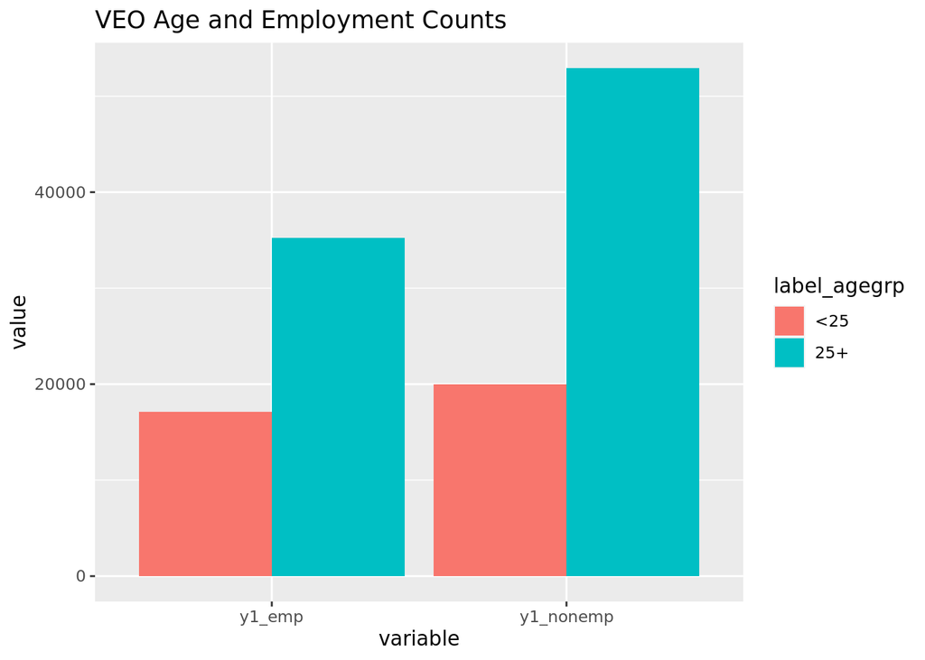

```r
# Age at enlistment
veo_age_long <- veo_age %>% select(label_cohort, label_agegrp, y1_emp, y1_nonemp) %>% melt(id.vars = c("label_cohort", "label_agegrp"))

veo_age_long$value <- as.numeric(veo_age_long$value)

ggplot(veo_age_long, aes(x = variable, y = value, fill = label_agegrp)) +
  geom_col(position = "dodge") +
  labs(title = "VEO Age and Employment Counts")
```

# Sex and Employment Counts

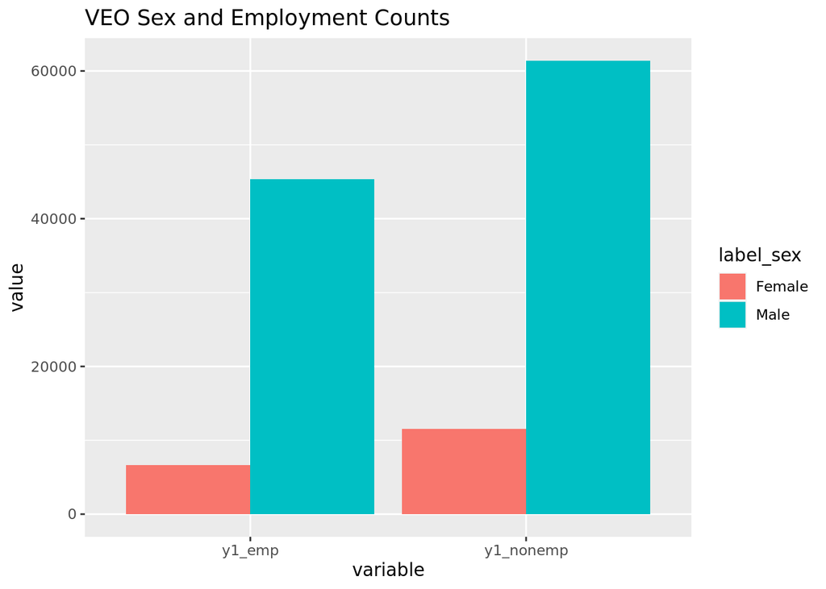

```r
veo_sex_long <- veo_sex %>% select(label_cohort, label_sex, y1_emp, y1_nonemp) %>% melt(id.vars = c("label_cohort", "label_sex"))

veo_sex_long$value <- as.numeric(veo_sex_long$value)

ggplot(veo_sex_long, aes(x = variable, y = value, fill = label_sex)) +
  geom_col(position = "dodge") +
  labs(title = "VEO Sex and Employment Counts")
```

# Education and Employment Counts

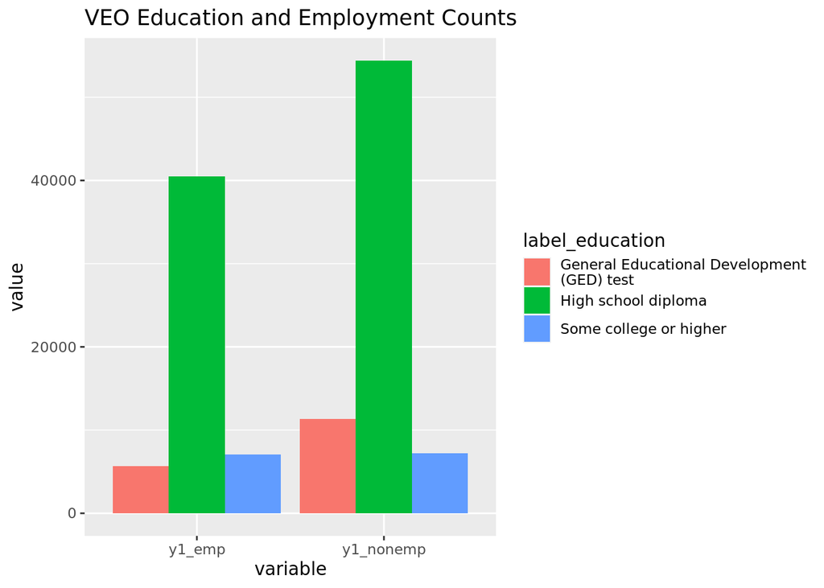

```r
#Education at enlistment
veo_edu_long <- veo_edu %>% select(label_cohort, label_education, y1_emp, y1_nonemp) %>% melt(id.vars = c("label_cohort", "label_education"))

veo_edu_long$value <- as.numeric(veo_edu_long$value)

ggplot(veo_edu_long, aes(x = variable, y = value, fill = label_education)) +
  geom_col(position = "dodge") +
  labs(title = "VEO Education and Employment Counts")
```

# Race and Employment Counts

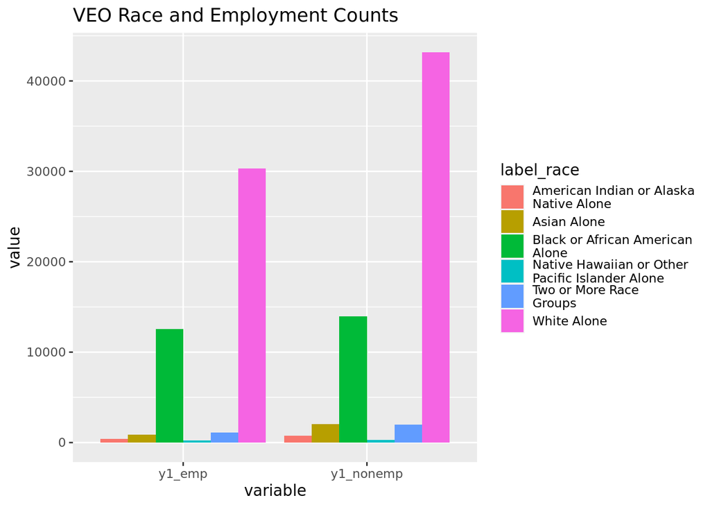

```r
veo_race_long <- veo_race %>% select(label_cohort, label_race, label_ethnicity, y1_emp, y1_nonemp) %>% melt(id.vars = c("label_cohort", "label_race", "label_ethnicity"))

veo_race_long$value <- as.numeric(veo_race_long$value)

ggplot(veo_race_long, aes(x = variable, y = value, fill = label_race)) +
  geom_col(position = "dodge") +
  labs(title = "VEO Race and Employment Counts")
```

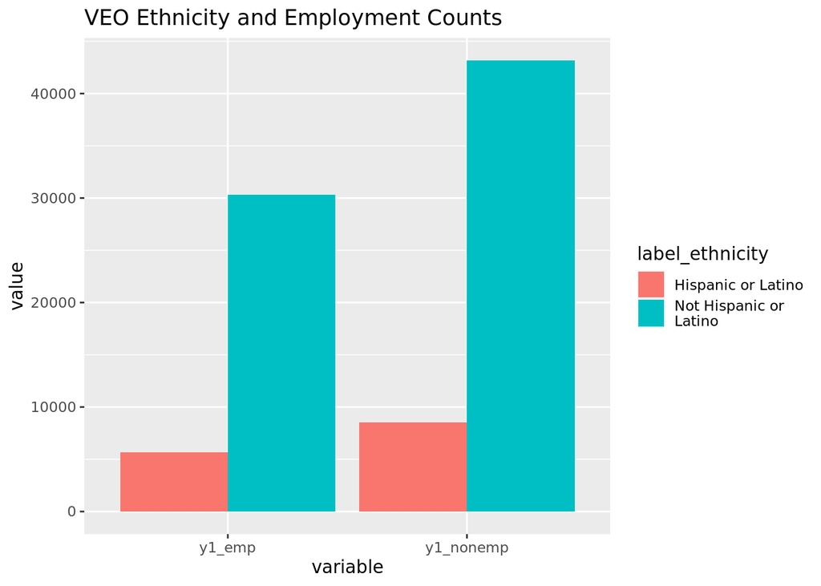

```r
ggplot(veo_race_long, aes(x = variable, y = value, fill = label_ethnicity)) +
  geom_col(position = "dodge") +
  labs(title = "VEO Ethnicity and Employment Counts")
```

# VEO Occupation and Employment Counts

```r
# Read in crosswalk between DOD and SOC codes
crosswalk <- read_csv("~/git/DSPG2020/career/src/lehd/milx0120.csv")
military <- read_csv("~/git/DSPG2020/career/src/lehd/Military_Specific.csv")
```

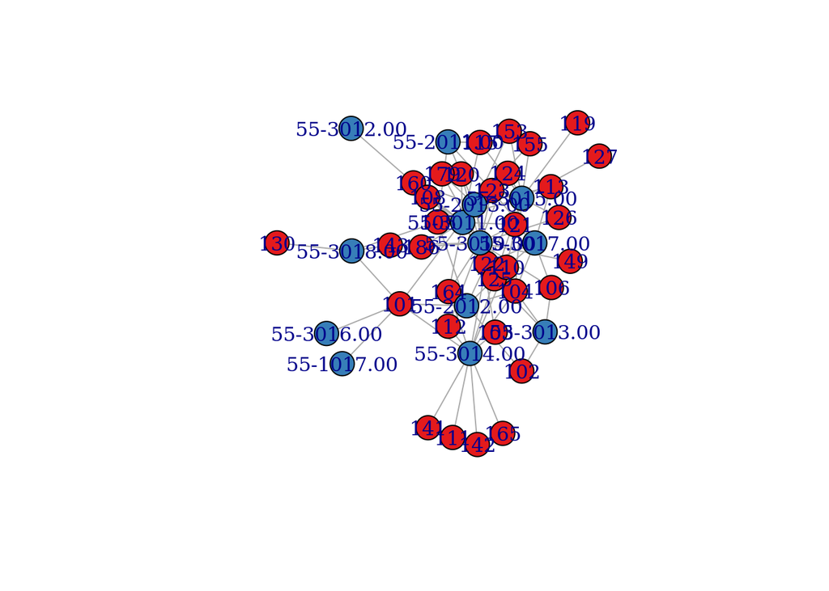

```r
mil_crosswalk <- crosswalk %>% select(DODOCC, ONET1) %>% filter(ONET1 %in% military$Code) %>% transmute(DODOCC = str_extract(DODOCC, "[0-9][0-9][0-9]"), ONET1) %>% distinct() %>% filter(DODOCC <= 186)

mil_crosswalk_nodes <- gather(mil_crosswalk) %>% select(value, key) %>% distinct()

net <- graph_from_data_frame(d=mil_crosswalk, vertices = mil_crosswalk_nodes, directed = F)

library(RColorBrewer)
coul  <- brewer.pal(2, "Set1")
my_color <- coul[as.numeric(as.factor(V(net)$key))]

plot(net, vertex.color=my_color)
```

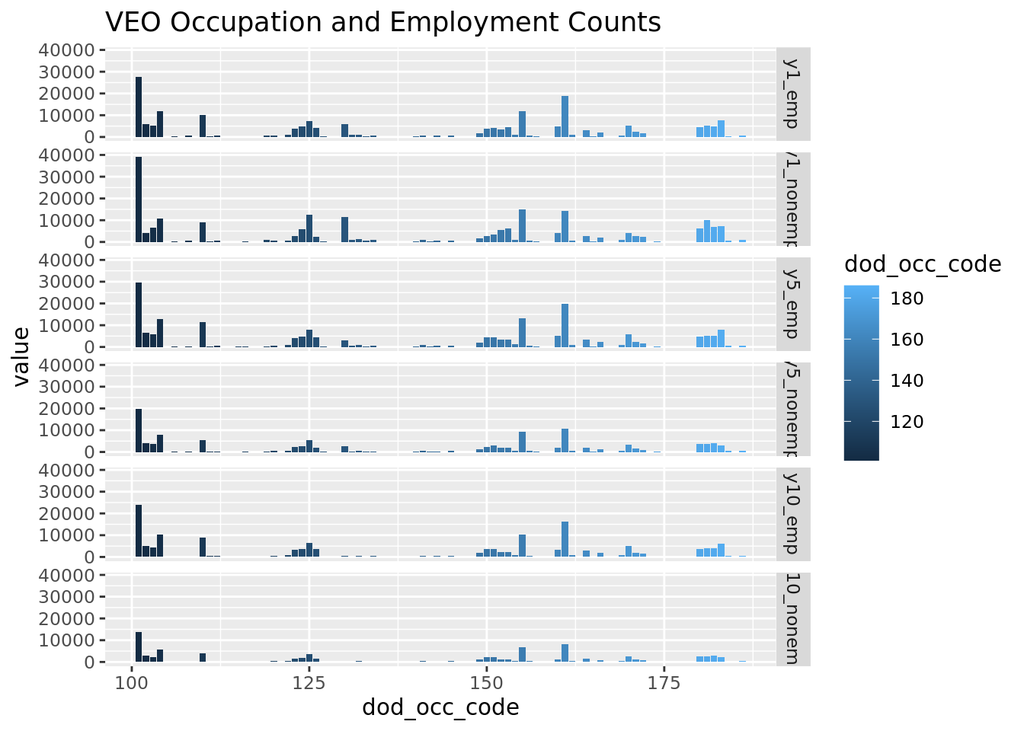

```r
veo_occ_long <- veo_occ %>% select(label_cohort, dod_occ_code, y1_emp, y1_nonemp, y5_emp, y5_nonemp, y10_emp, y10_nonemp) %>% melt(id.vars = c("label_cohort", "dod_occ_code"))

veo_occ_long$value <- as.numeric(veo_occ_long$value)

ggplot(veo_occ_long, aes(x = dod_occ_code, y = value, fill = dod_occ_code)) +
  geom_col(position = "dodge") +
  facet_grid(rows = vars(variable)) +
  labs(title = "VEO Occupation and Employment Counts")
```

# VEO Industry and Employment Counts

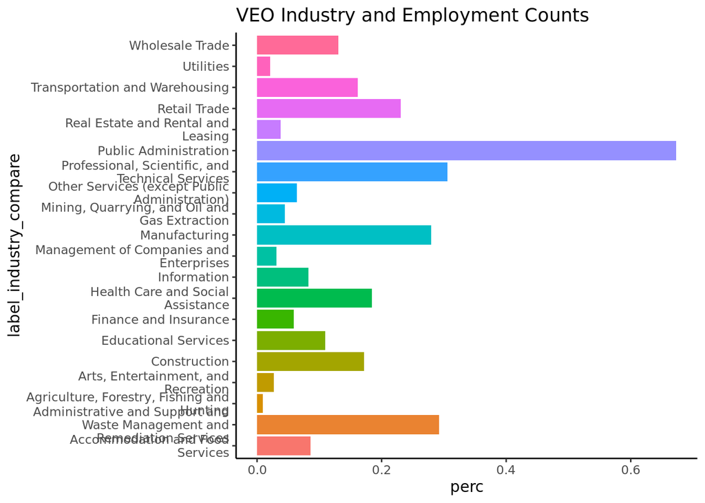

```r
# Create long df of veo industries
veo_ind_long <- veo_ind %>% select(label_cohort, label_industry, industry, y1_emp, y5_emp, y10_emp) %>% melt(id.vars = c("label_cohort", "label_industry", "industry"))

veo_ind_long$value <- as.integer(veo_ind_long$value)

# Remove created federal government industry code for comparison
veo_ind_long<- veo_ind_long %>% mutate(industry_compare = ifelse(industry == 99, 92, industry)) %>% mutate(label_industry_compare = ifelse(industry == 99, "Public Administration", label_industry))

# Calculate percentage in industries
veo_ind_long_perc <- veo_ind_long %>% drop_na() %>% group_by(variable) %>% mutate(perc = value/sum(value))

# Plot
ggplot(veo_ind_long_perc, aes(x = label_industry_compare, y = perc, fill = label_industry_compare)) +
  geom_col(show.legend = FALSE) +
  labs(title = "VEO Industry and Employment Counts") +
  #facet_grid(rows = vars(variable)) +
  coord_flip() +
  theme_classic()
```

```r
# Create pattern for military ids and gather ids
military <- "55-[0-9][0-9][0-9][0-9].[0-9][0-9]"
military_ids <- job %>% filter(str_detect(job$onet, military)) %>% distinct(id)

# Create df of resumes for military ids, get counts in each sector
res_mil <- job %>% filter(id %in% military_ids$id) %>% group_by(sector) %>% summarise(n = n()) %>% drop_na()
```

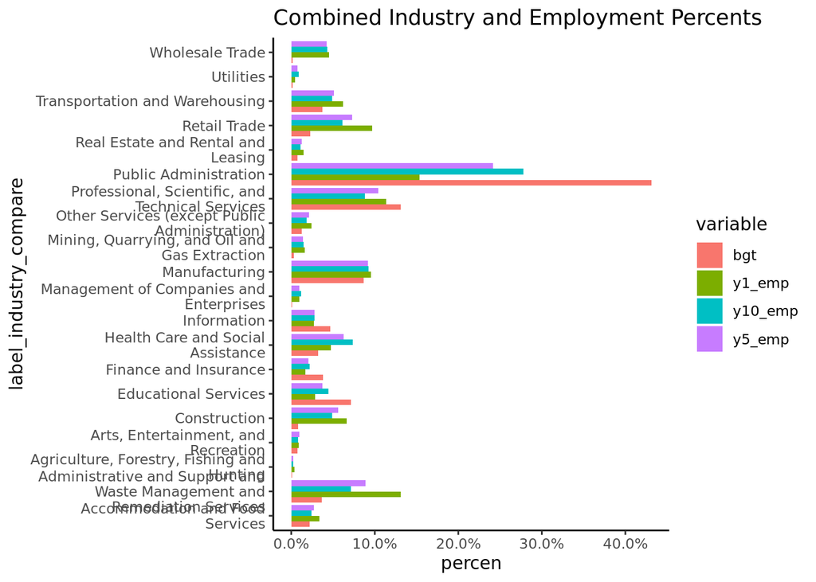

```r
# Join industry labels by NAICS codes
res_mil_labels <- res_mil %>% left_join(select(veo_ind_long, label_industry, industry), by = c("sector" = "industry"))

# Calculate percent in each sector, prepare dfs for rbind
res_mil_labels <- res_mil_labels %>% distinct() %>% mutate(perc = n/sum(n)) %>% mutate(variable = "bgt") %>% rename(value = n, label_industry_compare = label_industry, industry_compare = sector)

veo_ind_long_perc <- veo_ind_long_perc %>% select(variable, value, industry_compare, label_industry_compare, perc)

#Rbind
veo_bgt_industry_profile <- rbind(veo_ind_long_perc, res_mil_labels)

#Sum industry percent
veo_bgt_industry_profile <- veo_bgt_industry_profile %>% group_by(variable, industry_compare) %>% mutate(percen = sum(perc))

ggplot(veo_bgt_industry_profile, aes(x = label_industry_compare, y = percen, fill = variable)) +
  geom_col(position = "dodge") +
  labs(title = "Combined Industry and Employment Percents") +
  scale_y_continuous(labels = scales::percent) +
  coord_flip() +
  theme_classic()
```

```r
lodes <- read_excel("~/git/DSPG2020/career/src/lehd/otm.xls", sheet = 1, range = "A24:AG45")
```

```
## * `` -> ...1
## * `` -> ...3
## * `` -> ...5
## * `` -> ...7
## * `` -> ...9
## * ...
```

```r
lodes <- lodes %>% rename("label_industry" = "...1", "count_2017" = "2017", "share_2017" = "...3", "count_2016" = "2016", "share_2016" = "...5", "count_2015" = "2015", "share_2015" = "...7", "count_2014" = "2014", "share_2014" = "...9", "count_2013" = "2013", "share_2013" = "...11", "count_2012" = "2012", "share_2012" = "...13", "count_2011" = "2011", "share_2011" = "...15","count_2010" = "2010", "share_2010" = "...17", "count_2009" = "2009", "share_2009" = "...19", "count_2008" = "2008", "share_2008" = "...21", "count_2007" = "2007", "share_2007" = "...23", "count_2006" = "2006", "share_2006" = "...25", "count_2005" = "2005", "share_2005" = "...27", "count_2004" = "2004", "share_2004" = "...29", "count_2003" = "2003", "share_2003" = "...31", "count_2002" = "2002", "share_2002" = "...33")

# Remove first row
lodes <- lodes[-c(1), ]

# Change to long
lodes <- lodes %>% select("label_industry", contains("share")) %>% melt(id.vars = c("label_industry"))

lodes$value <- as.numeric(lodes$value)

#Summarise percent by industry, add lodes variable for rbind
lodes_sum <- lodes %>% group_by(label_industry) %>% summarise(percen = mean(value)) %>% mutate(variable = "lodes")
# Check for differences in labels
unique(lodes_sum$label_industry)
```

```
##  [1] "Accommodation and Food Services"
##  [2] "Administration & Support, Waste Management and Remediation"
##  [3] "Agriculture, Forestry, Fishing and Hunting"
##  [4] "Arts, Entertainment, and Recreation"
##  [5] "Construction"
##  [6] "Educational Services"
##  [7] "Finance and Insurance"
##  [8] "Health Care and Social Assistance"
##  [9] "Information"
## [10] "Management of Companies and Enterprises"
## [11] "Manufacturing"
## [12] "Mining, Quarrying, and Oil and Gas Extraction"
## [13] "Other Services (excluding Public Administration)"
## [14] "Professional, Scientific, and Technical Services"
## [15] "Public Administration"
## [16] "Real Estate and Rental and Leasing"
## [17] "Retail Trade"
## [18] "Transportation and Warehousing"
## [19] "Utilities"
## [20] "Wholesale Trade"
```

```r
unique(veo_bgt_industry_profile$label_industry_compare)
```

```
##  [1] "Agriculture, Forestry, Fishing and\nHunting"
##  [2] "Mining, Quarrying, and Oil and\nGas Extraction"
##  [3] "Utilities"
##  [4] "Construction"
##  [5] "Manufacturing"
##  [6] "Wholesale Trade"
##  [7] "Retail Trade"
##  [8] "Transportation and Warehousing"
##  [9] "Information"
## [10] "Finance and Insurance"
## [11] "Real Estate and Rental and\nLeasing"
## [12] "Professional, Scientific, and\nTechnical Services"
## [13] "Management of Companies and\nEnterprises"
## [14] "Administrative and Support and\nWaste Management and\nRemediation Services"
## [15] "Educational Services"
## [16] "Health Care and Social\nAssistance"
## [17] "Arts, Entertainment, and\nRecreation"
## [18] "Accommodation and Food\nServices"
## [19] "Other Services (except Public\nAdministration)"
## [20] "Public Administration"
```

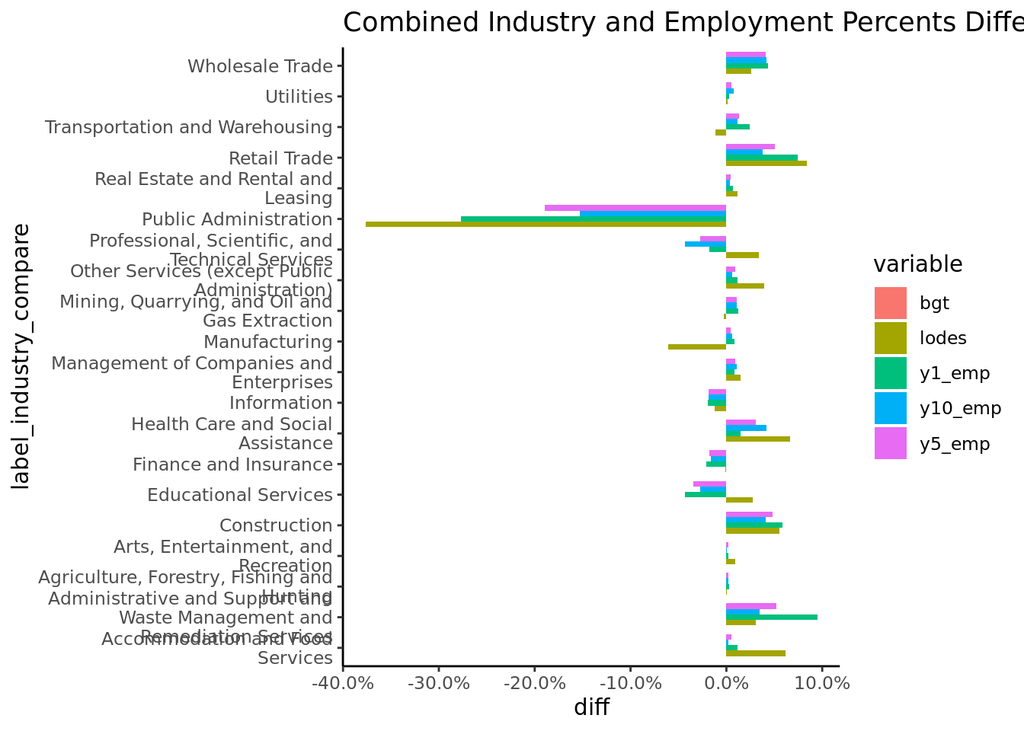

```r
# Add compared labels

labels <- unique(veo_bgt_industry_profile$label_industry_compare) %>% sort()

lodes_sum <- lodes_sum %>% mutate(label_industry_compare = labels)
# Check for matches, looks good!
# Remove old industry labels for rbind
lodes_sum <- lodes_sum %>% select(-label_industry)

# Deselect perc column
veo_bgt_industry_profile <- veo_bgt_industry_profile %>% select(-c(perc, value))

# Rbind
all_industry_profile <- rbind(veo_bgt_industry_profile, lodes_sum)

# Add bgt percent reference column, calculate bgt percent difference
all_industry_profile <- all_industry_profile %>% left_join(select(res_mil_labels, perc, label_industry_compare), by = "label_industry_compare") %>% rename(bgt_percent = perc) %>% mutate(diff = percen - bgt_percent) %>% mutate(percent_diff = diff/percen)


ggplot(all_industry_profile, aes(filter(variable != bgt), x = label_industry_compare, y = diff, fill = variable)) +
  geom_col(position = "dodge") +
  labs(title = "Combined Industry and Employment Percents Difference from BGT") +
  scale_y_continuous(labels = scales::percent) +
  coord_flip() +
  theme_classic()
```

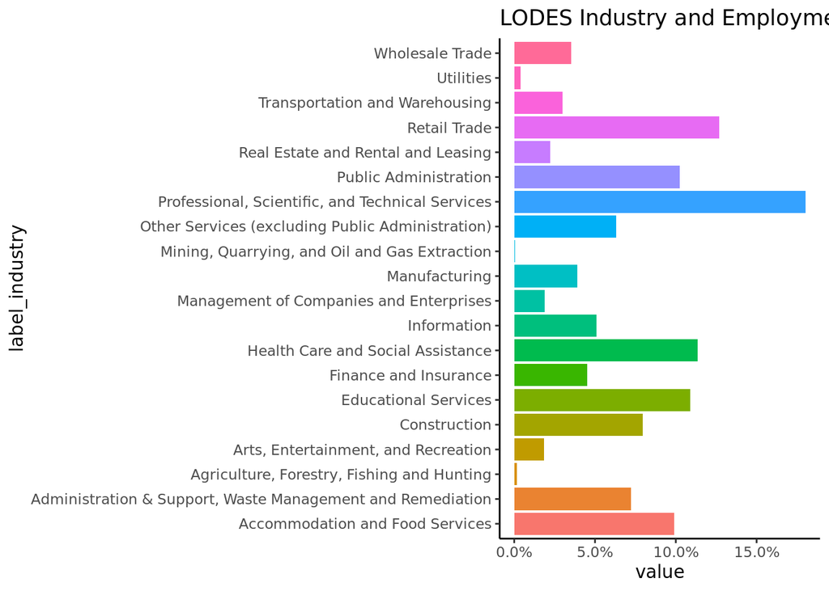

```r
ggplot(lodes, aes(x = label_industry, y = value, fill = label_industry)) +
  geom_col(position = "dodge", show.legend = FALSE) +
  labs(title = "LODES Industry and Employment Percents") +
  scale_y_continuous(labels = scales::percent) +
  coord_flip() +
  theme_classic()
```

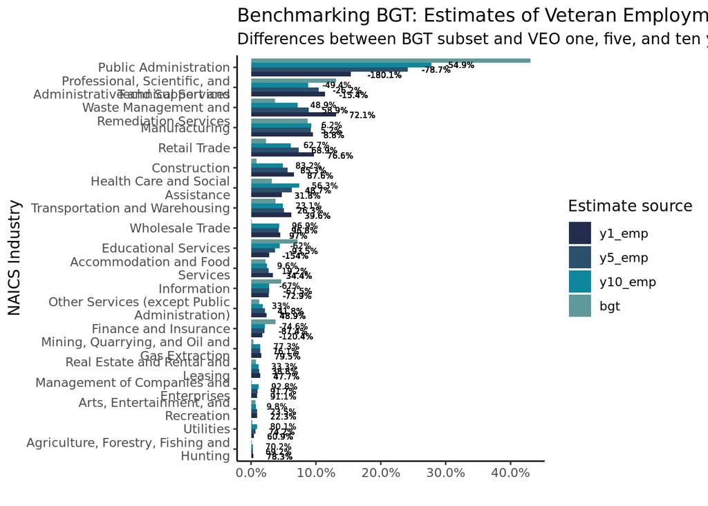

```r
uvapal = c("#232d4b","#2c4f6b","#0e879c","#60999a","#d1e0bf","#d9e12b","#e6ce3a","#e6a01d","#e57200","#fdfdfd")

all_industry_profile %>%
  filter(variable != "lodes") %>%
  mutate(diff_lab = ifelse(diff == 0, NA, (paste0(round(percent_diff*100, digits = 1),"%")))) %>%
  mutate(position = ifelse(variable == "y1_emp", 1,
                           ifelse(variable == "y5_emp", 2,
                                  ifelse(variable == "y10_emp", 3, 4)))) %>%
  arrange(position) %>%
  ggplot(aes(x = reorder(label_industry_compare, percen), y = percen,
             fill = reorder(variable, position))) +
  geom_col(position = "dodge") +
  labs(title = "Benchmarking BGT: Estimates of Veteran Employment by Industry",
       subtitle = "Differences between BGT subset and VEO one, five, and ten year bins",
       fill = "Estimate source") +
  xlab("NAICS Industry") +
  ylab("") +
  scale_y_continuous(labels = scales::percent) +
  scale_fill_discrete(labels = c("VEO 1 year", "VEO 5 year", "VE0 10 year", "BGT")) +
  geom_text(aes(x = label_industry_compare,
                y = percen,
                label = diff_lab,
                fill = reorder(variable, position)),
            position = position_dodge(width = 1),
            hjust = -0.5, size = 2) +
    scale_fill_manual(values = uvapal) +
  coord_flip() +
  theme_classic()
```

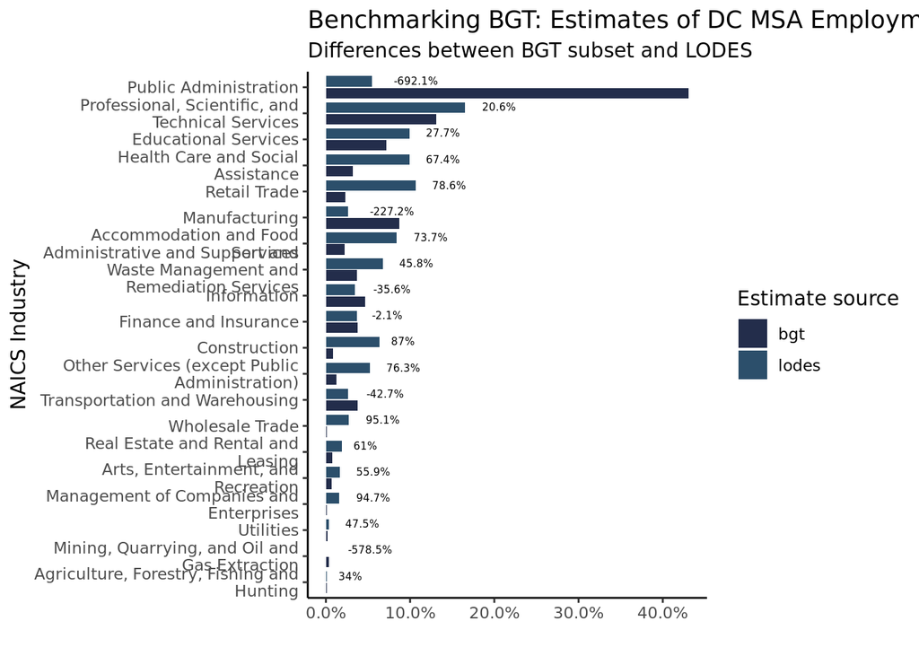

```r
all_industry_profile %>%
  filter(!(variable %in% c("y1_emp", "y5_emp", "y10_emp"))) %>%
  mutate(diff_lab = ifelse(diff == 0, NA, (paste0(round(percent_diff*100, digits = 1),"%")))) %>%
  ggplot(aes(x = reorder(label_industry_compare, percen), y = percen,
             fill = variable)) +
  geom_col(position = position_dodge2(width = 1, preserve = "single")) +
  labs(title = "Benchmarking BGT: Estimates of DC MSA Employment by Industry",
       subtitle = "Differences between BGT subset and LODES",
       fill = "Estimate source") +
  xlab("NAICS Industry") +
  ylab("") +
  scale_y_continuous(labels = scales::percent) +
  scale_fill_discrete(labels = c("BGT", "LODES")) +
  geom_text(aes(x = label_industry_compare,
                y = percen,
                label = diff_lab,
                fill = variable),
            position = position_dodge2(width = 1, preserve = "single"),
            hjust = -0.5, size = 2) +
  scale_fill_manual(values = uvapal) +
  coord_flip() +
  theme_classic()
```